# Reproducible Research: Peer Assessment 1

## Setting global options

```r
    library(knitr)
    opts_chunk$set(echo=TRUE)
```

## Loading and preprocessing the data

```r
    unzip("activity.zip")
    df <- read.csv("activity.csv", header=TRUE)
    df$date <- as.Date(df$date)
```

## What is mean total number of steps taken per day?

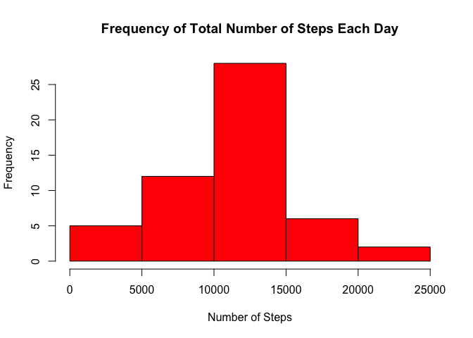

```r
    good <- complete.cases(df)
    df2 <- aggregate(x=list(Steps = df[good,]$steps), by=list(Date = df[good,]$date), FUN=sum)
    hist(df2$Steps, col = "red", main = "Frequency of Total Number of Steps Each Day",
         xlab = "Number of Steps", ylab = "Frequency")
```

```r
    meanSteps <- mean(df2$Steps)
    medianSteps <- median(df2$Steps)
```

The mean total number of steps taken per day is 1.0766 × 10<sup>4</sup>.  
The median total number of steps taken per day is 10765.

## What is the average daily activity pattern?

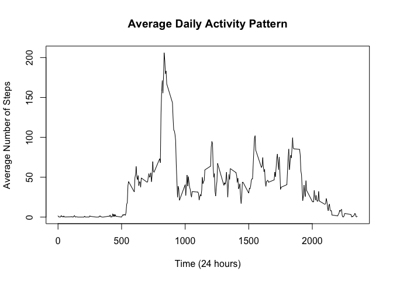

```r
    df3 <- aggregate(x=list(MeanSteps = df[good,]$steps), by=list(Interval = df[good,]$interval), FUN=mean)
    with(df3, plot(Interval, MeanSteps, type = "l",
                    xlab = "Time (24 hours)",
                    ylab = "Average Number of Steps",
                    main = "Average Daily Activity Pattern"))
```

```r
    mostActiveInterval <- df3[df3$MeanSteps == max(df3$MeanSteps), ]$Interval
```

The most active time, on average, is 835.

## Imputing missing values

Missing values are obtained by looking only at complete cases and getting the mean number of steps for each interval from those cases and updating the missing values based on their associated interval value.

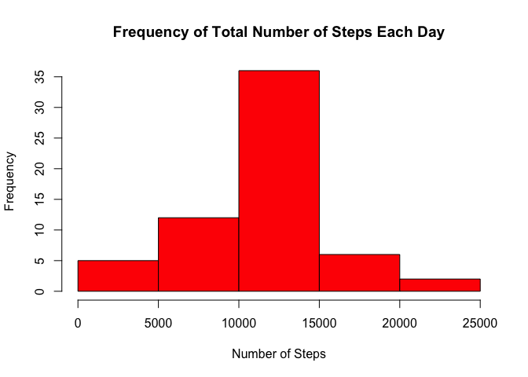

```r
    missingCount <- nrow(df[!good,])
    df4 <- merge(df, df3, by.x = "interval", by.y = "Interval")
    df4$steps[is.na(df4$steps)] <- df4$MeanSteps[is.na(df4$steps)]

    df5 <- aggregate(x=list(Steps = df4$steps), by=list(Date = df4$date), FUN=sum)
    hist(df5$Steps, col = "red", main = "Frequency of Total Number of Steps Each Day",
         xlab = "Number of Steps", ylab = "Frequency")
```

```r
    meanStepsEst <- mean(df5$Steps)
    medianStepsEst <- median(df5$Steps)
```

The number of rows with missing values is 2304.  
The mean total number of steps taken per day is 1.0766 × 10<sup>4</sup>.  
The median total number of steps taken per day is 1.0766 × 10<sup>4</sup>.

These values do not differ significantly from previous estimates. There is virtually no impact from imputing missing data.

## Are there differences in activity patterns between weekdays and weekends?

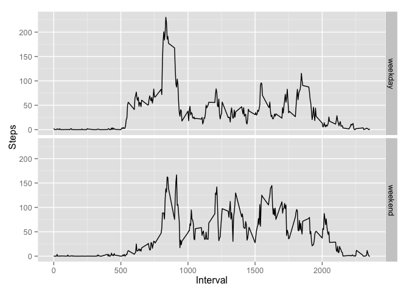

```r
    library(ggplot2)
    df4$daytype <- factor(ifelse(!weekdays(df4$date) %in% c("Saturday", "Sunday"),
                                 "weekday", "weekend"))
    df6 <- aggregate(x=list(Steps = df4$steps),
                     by=list(Interval = df4$interval, DayType = df4$daytype ),
                     FUN=mean)
    qplot(Interval, Steps, data=df6, facets = DayType ~ ., geom="line")
```

There is about one third greater activity during the weekdays around the 8:30 AM time period than on the weekends. However, activity drops after that during the week for the rest of the day, while it stays at a higher level through the weekend days.